# Project Report: Increase Economic Activity & Quality of Life in the South Stockton Promise Zone

### By:Shyla C. Solis & Trang Vu

### 1. Objective:

There has been outreach from not only public members, but community members , and local representatives to highlight the need for a condition improvement in South Stockton. In order to meet the needs, Stockton city mayor, Michael Tubbs, created a Coalition, “to catalyze the collective impact needed to improve the conditions in the community”. Through an attempt to transform the community, partners from all around the community have joined together to create one vision. As a result, San Joaquin Council of Governments (SJCOG) bacme the Backbone of the Community Vision/Collective Impact Model, Result 8, focused on increasing Economic Activity & Quality of Life. In order to make a difference in these areas, SJCOG needs to know more about the people in the South Stockton Promise Zone (SSPZ).

We will forecast over 5 years to show what will happen if South Stocktons economic and level ofquality life is not recognized. Using our predictors, we hope will help manipulate the over all metric chosen, which is household burden costs while considering other factors such as health, education, rent, income, population and others.

### 2. Data Exploration:

Reading in our data file to explore the story behind the city of Stockton, California. The head(), function shows the type each column is storing, along with the names of each column.

```r
# mGROSSR: Contains the median gross rent as a percentage of household
# income.
mGROSSr<-read.csv("acs_17_5yr_b25071_with_ann.csv", header=TRUE, sep=',')
```

```r
head(mGROSSr)
```

A data.frame: 6 × 5

[output not shown]

```r
# vehicleANDhousing: Contains information about the number of vehicles within each
# zipcode a person owns.
# As well as information about the number of people renting versus owning a house
# per zipcode.
vehicleANDhousing<-read.csv("ACS_17_5YR_S0802_with_ann.csv", header=TRUE, sep=',')
head(vehicleANDhousing)
```

A data.frame: 6 × 811

| GEO.id <fct> | GEO.id2 <int> | GEO.display.label <fct> | HC01_EST_VC01 <int> | HC01_MOE_VC01 <int> | HC02_EST_VC01 <int> | HC02_MOE_VC01 <int> | HC03_EST_VC01 <int> | HC03_MOE_VC01 <int> | HC04_EST_VC01 <int> | ... | HC04_EST_VC134 <fct> | HC04_MOE_VC134 <fct> | HC01_EST_VC135 <fct> | HC01_MOE_VC135 <fct> | HC02_EST_VC135 <fct> | HC02_MOE_VC135 <fct> | HC03_EST_VC135 <fct> | HC03_MOE_VC135 <fct> | HC04_EST_VC135 <fct> | HC04_MOE_VC135 <fct> |
| --- | --- | --- | --- | --- | --- | --- | --- | --- | --- | --- | --- | --- | --- | --- | --- | --- | --- | --- | --- | --- |
| 8600000US89010 | 89010 | ZCTA5 89010 | 216 | 73 | 103 | 52 | 17 | 15 | 7 | ... | (X) | (X) | 0.0 | (X) | (X) | (X) | (X) | (X) | (X) | (X) |
| 8600000US89019 | 89019 | ZCTA5 89019 | 759 | 173 | 431 | 162 | 12 | 20 | 1 | ... | (X) | (X) | 0.4 | (X) | (X) | (X) | (X) | (X) | (X) | (X) |
| 8600000US89046 | 89046 | ZCTA5 89046 | 153 | 77 | 116 | 70 | 0 | 12 | 0 | ... | (X) | (X) | 9.2 | (X) | (X) | (X) | (X) | (X) | (X) | (X) |
| 8600000US89060 | 89060 | ZCTA5 89060 | 2725 | 451 | 2037 | 366 | 523 | 215 | 0 | ... | (X) | (X) | 0.0 | (X) | (X) | (X) | (X) | (X) | (X) | (X) |
| 8600000US89061 | 89061 | ZCTA5 89061 | 1539 | 319 | 1204 | 297 | 101 | 82 | 0 | ... | (X) | (X) | 4.2 | (X) | (X) | (X) | (X) | (X) | (X) | (X) |
| 8600000US89439 | 89439 | ZCTA5 89439 | 651 | 171 | 481 | 137 | 99 | 72 | 0 | ... | (X) | (X) | 2.0 | (X) | (X) | (X) | (X) | (X) | (X) | (X) |

```r
# education: Contains information on the amount of people who have a bachelors
# degree, as well as the amount of people who have less than high school.
education<-read.csv("ACS_17_5YR_S1501_with_ann.csv", header=TRUE, sep=',')
head(education)
```

A data.frame: 6 × 771

| GEO.id <fct> | GEO.id2 <int> | GEO.display.label <fct> | HC01_EST_VC02 <int> | HC01_MOE_VC02 <int> | HC02_EST_VC02 <fct> | HC02_MOE_VC02 <fct> | HC03_EST_VC02 <int> | HC03_MOE_VC02 <int> | HC04_EST_VC02 <fct> | ... | HC02_EST_VC85 <fct> | HC02_MOE_VC85 <fct> | HC03_EST_VC85 <fct> | HC03_MOE_VC85 <fct> | HC04_EST_VC85 <fct> | HC04_MOE_VC85 <fct> | HC05_EST_VC85 <fct> | HC05_MOE_VC85 <fct> | HC06_EST_VC85 <fct> | HC06_MOE_VC85 <fct> |
| --- | --- | --- | --- | --- | --- | --- | --- | --- | --- | --- | --- | --- | --- | --- | --- | --- | --- | --- | --- | --- |
| 8600000US89010 | 89010 | ZCTA5 89010 | 51 | 42 | (X) | (X) | 9 | 10 | (X) | ... | (X) | (X) | - | ** | (X) | (X) | - | ** | (X) | (X) |
| 8600000US89019 | 89019 | ZCTA5 89019 | 43 | 39 | (X) | (X) | 33 | 36 | (X) | ... | (X) | (X) | - | ** | (X) | (X) | - | ** | (X) | (X) |
| 8600000US89046 | 89046 | ZCTA5 89046 | 24 | 26 | (X) | (X) | 13 | 19 | (X) | ... | (X) | (X) | - | ** | (X) | (X) | - | ** | (X) | (X) |
| 8600000US89060 | 89060 | ZCTA5 89060 | 415 | 149 | (X) | (X) | 295 | 117 | (X) | ... | (X) | (X) | 63482 | 39969 | (X) | (X) | - | ** | (X) | (X) |
| 8600000US89061 | 89061 | ZCTA5 89061 | 75 | 55 | (X) | (X) | 46 | 36 | (X) | ... | (X) | (X) | - | ** | (X) | (X) | 96618 | 65897 | (X) | (X) |
| 8600000US89439 | 89439 | ZCTA5 89439 | 83 | 71 | (X) | (X) | 45 | 43 | (X) | ... | (X) | (X) | - | ** | (X) | (X) | 60068 | 25863 | (X) | (X) |

```r
population<-read.csv("ACS_17_5YR_B01003_with_ann.csv", header=TRUE, sep=',')
head(population)
```

A data.frame: 6 × 5

| GEO.id <fct> | GEO.id2 <int> | GEO.display.label <fct> | HD01_VD01 <int> | HD02_VD01 <int> |
| --- | --- | --- | --- | --- |
| 8600000US89010 | 89010 | ZCTA5 89010 | 512 | 130 |
| 8600000US89019 | 89019 | ZCTA5 89019 | 1748 | 553 |
| 8600000US89046 | 89046 | ZCTA5 89046 | 354 | 99 |
| 8600000US89060 | 89060 | ZCTA5 89060 | 9373 | 838 |
| 8600000US89061 | 89061 | ZCTA5 89061 | 5360 | 584 |
| 8600000US89439 | 89439 | ZCTA5 89439 | 1465 | 232 |

```r
# Reading the Zipcode file for USA
zipcodes.USA<-read.csv("Zipcode list for USA.csv", header=TRUE, sep=',')
head(zipcodes.USA)
```

A data.frame: 6 × 3

| Zipcode <int> | City <fct> | County <fct> |
| --- | --- | --- |
| 90001 | Los Angeles | Los Angeles |
| 90002 | Los Angeles | Los Angeles |
| 90003 | Los Angeles | Los Angeles |
| 90004 | Los Angeles | Los Angeles |
| 90005 | Los Angeles | Los Angeles |
| 90006 | Los Angeles | Los Angeles |

```r
# Reading the Zipcode file for San Joaquin
zipcodes.SJC<-read.csv("Zipcode list for San Joaquin County.csv", header=TRUE, sep=',')
head(zipcodes.SJC)
```

A data.frame: 6 × 3

| Zipcoode <int> | City <fct> | County <fct> |
| --- | --- | --- |
| 95201 | Stockton | San Joaquin |
| 95202 | Stockton | San Joaquin |
| 95203 | Stockton | San Joaquin |
| 95204 | Stockton | San Joaquin |
| 95205 | Stockton | San Joaquin |
| 95206 | Stockton | San Joaquin |

```r
zipcodes.STKN<-read.csv("Zipcode list for Stockton.csv", header=TRUE, sep=',')
head(zipcodes.STKN)
```

A data.frame: 6 × 3

| Zipcode <int> | City <fct> | County <fct> |
| --- | --- | --- |
| 95201 | Stockton | San Joaquin |
| 95202 | Stockton | San Joaquin |
| 95203 | Stockton | San Joaquin |
| 95204 | Stockton | San Joaquin |
| 95205 | Stockton | San Joaquin |
| 95206 | Stockton | San Joaquin |

### Let's dive a little deeper into the information!

###### Let's look at "mGROSSr":

```r
str(mGROSSr)
```

```
'data.frame':	1775 obs. of  5 variables:
 $ GEO.id              : Factor w/ 1775 levels "8600000US89010",..: 1 2 3 4 5 6 7 8 9 10 ...
 $ GEO.id2             : int  89010 89019 89046 89060 89061 89439 90001 90002 90003 90004 ...
 $ GEO.display33.2label: Factor w/ 1775 levels "ZCTA5 89010",..: 1 2 3 4 5 6 7 8 9 10 ...
 $ HD01_VD01           : num  17.5 26.3 24.2 28.3 21.8 32.4 41.3 43.3 48.8 33.8 ...
 $ HD02_VD01           : Factor w/ 246 levels "**","***","0.8",..: 21 152 228 193 234 178 101 146 103 5 ...
```

While using the function str(), we are able to gain insight as to how big the data frame is and what types are being stored. For example, GEO.id is a factor storing 1775 different factors.

```r
# Find out names of columns
names(mGROSSr)
```

1. 'GEO.id'

2. 'GEO.id2'

3. 'GEO.display33.2label'

4. 'HD01_VD01'

5. 'HD02_VD01'

Above is a display of the different names of each of the columns stored in the data frame, "mGROSSr". These names are not meaningful, we can change them using the function below.

```r
colnames(mGROSSr) <- c("ID","Zipcode", "GEO.display.label", "Rent.to.Income.Ratio", "HD02_VD01")
```

```r
names(mGROSSr)
```

1. 'ID'

2. 'Zipcode'

3. 'GEO.display.label'

4. 'Rent.to.Income.Ratio'

5. 'HD02_VD01'

We can also check to see how many rows and columns the data frame has using the following functions:

```r
nrow(mGROSSr)
```

1775

```r
ncol(mGROSSr)
```

5

Hence, "mGROSSr" has 1775 rows and 5 columns.

##### Let's look at "vehicleANDhousing":

Let's start off by first looking at how many rows and columns it has:

```r
nrow(vehicleANDhousing)
```

1775

```r
ncol(vehicleANDhousing)
```

811

Since this data frame is so big, we wont want to use the function str() here; it will print out too many lines of information. We will instead wait until we strip off what we don't wnat from the data frame.

###### Let's look at "education":

We will also start here by looking the size, since we don't know how bid the data frame is:

```r
dim(education)
```

1. 1775

2. 771

This time we used the function dim() to find the dimensions of the data frame which tells us, "education" has 1775 rows and 771 columns. This data frame s also too large to dive deeper into right now. With that being said, lets start cleaning!

First let's check the size of the data.

```r
dim(population)
```

1. 1775

2. 5

Since there are not too many rows, here are the names of the columns:

```r
names(population)
```

1. 'GEO.id'

2. 'GEO.id2'

3. 'GEO.display.label'

4. 'HD01_VD01'

5. 'HD02_VD01'

Theres not much too explore with the remaining data frames except for their sizes. Other than that, their outputs will just overload space.

### 3. Data Cleaning:

Since we will not be using every column, we will create a new data frame consisting only the columns which contain useful information.

```r
new_mGROSSr<-data.frame(mGROSSr$ID, mGROSSr$Zipcode, mGROSSr$Rent.to.Income.Ratio)
```

```r
head(new_mGROSSr)
```

A data.frame: 6 × 3

| mGROSSr.ID <fct> | mGROSSr.Zipcode <int> | mGROSSr.Rent.to.Income.Ratio <dbl> |
| --- | --- | --- |
| 8600000US89010 | 89010 | 17.5 |
| 8600000US89019 | 89019 | 26.3 |
| 8600000US89046 | 89046 | 24.2 |
| 8600000US89060 | 89060 | 28.3 |
| 8600000US89061 | 89061 | 21.8 |
| 8600000US89439 | 89439 | 32.4 |

```r
colnames(new_mGROSSr)<-c("ID", "Zipcode", "Ratio")
```

```r
head(new_mGROSSr)
```

A data.frame: 6 × 3

| ID <fct> | Zipcode <int> | Ratio <dbl> |
| --- | --- | --- |
| 8600000US89010 | 89010 | 17.5 |
| 8600000US89019 | 89019 | 26.3 |
| 8600000US89046 | 89046 | 24.2 |
| 8600000US89060 | 89060 | 28.3 |
| 8600000US89061 | 89061 | 21.8 |
| 8600000US89439 | 89439 | 32.4 |

```r
new_vehicleANDhousing<-data.frame(vehicleANDhousing$GEO.id, vehicleANDhousing$GEO.id2,vehicleANDhousing$HC01_EST_VC122, vehicleANDhousing$HC01_EST_VC123,  vehicleANDhousing$HC01_EST_VC126, vehicleANDhousing$HC01_EST_VC127, vehicleANDhousing$HC01_EST_VC128, vehicleANDhousing$HC01_EST_VC129)
```

```r
new_education<-data.frame(education$GEO.id, education$GEO.id2, education$HC01_EST_VC14, education$HC01_EST_VC03, education$HC01_EST_VC04, education$HC01_EST_VC02, education$HC01_EST_VC08)
```

```r
new_population<-data.frame(population$GEO.id, population$GEO.id2, population$HD01_VD01)
```

```r
zip.USA<-data.frame(zipcodes.USA$Zipcode)
colnames(zip.USA)<-("Zipcode")
```

```r
head(zip.USA)
```

A data.frame: 6 × 1

| Zipcode <int> |
| --- |
| 90001 |
| 90002 |
| 90003 |
| 90004 |
| 90005 |
| 90006 |

```r
zip.SJC<-data.frame(zipcodes.SJC$Zipcoode)
colnames(zip.SJC)<-("Zipcode")
```

```r
zip.STKN<-data.frame(zipcodes.STKN$Zipcode)
```

```r
colnames(zip.STKN)<-("Zipcode")
```

```r
head(zip.STKN)
```

A data.frame: 6 × 1

| Zipcode <int> |
| --- |
| 95201 |
| 95202 |
| 95203 |
| 95204 |
| 95205 |
| 95206 |

Above are the new data frames we will be working with which are alot smaller. They are still big, but atleast we have filtered out what we will not be working with or uneccessary data.

Before moving on, we are going to give each column, names that are more meaningful.

```r
colnames(new_vehicleANDhousing)<-c("ID","Zipcode","Number.of.Owner.Occupied.Housing.Units","Number.of.Renter.Occupied.Housing.Units","Total.Num.of.People.With.No.Vehicles.Available","Total.Num.of.People.With.1.Vehicle.Available","Total.Num.of.People.With.2.Vehicles.Available","Total.Num.of.People.With.3.or.more.Vehicles.Available"  )
```

```r
colnames(new_education)<-c("ID", "Zipcode", "Total.Num.of.Bachelors.Degrees","Total.Num.of.People.Less.Than.Highschool", "Total.Num.Diploma.Received", "Total.Pop.18.24","Total.Pop.25.and.over")
```

```r
colnames(new_population)<-c("ID", "Zipcode", "Population")
```

Let's take a look at our new meaningful data frames:

```r
head(new_mGROSSr)
```

A data.frame: 6 × 3

| ID <fct> | Zipcode <int> | Ratio <dbl> |
| --- | --- | --- |
| 8600000US89010 | 89010 | 17.5 |
| 8600000US89019 | 89019 | 26.3 |
| 8600000US89046 | 89046 | 24.2 |
| 8600000US89060 | 89060 | 28.3 |
| 8600000US89061 | 89061 | 21.8 |
| 8600000US89439 | 89439 | 32.4 |

```r
head(new_vehicleANDhousing)
```

A data.frame: 6 × 8

| ID <fct> | Zipcode <int> | Number.of.Owner.Occupied.Housing.Units <fct> | Number.of.Renter.Occupied.Housing.Units <fct> | Total.Num.of.People.With.No.Vehicles.Available <fct> | Total.Num.of.People.With.1.Vehicle.Available <fct> | Total.Num.of.People.With.2.Vehicles.Available <fct> | Total.Num.of.People.With.3.or.more.Vehicles.Available <fct> |
| --- | --- | --- | --- | --- | --- | --- | --- |
| 8600000US89010 | 89010 | 26.3 | 73.7 | 0.0 | 19.6 | 43.5 | 36.8 |
| 8600000US89019 | 89019 | 47.8 | 52.2 | 21.5 | 38.5 | 29.0 | 10.9 |
| 8600000US89046 | 89046 | 51.6 | 48.4 | 0.0 | 55.6 | 44.4 | 0.0 |
| 8600000US89060 | 89060 | 72.1 | 27.9 | 0.0 | 9.6 | 44.8 | 45.6 |
| 8600000US89061 | 89061 | 78.6 | 21.4 | 0.0 | 16.6 | 53.7 | 29.7 |
| 8600000US89439 | 89439 | 75.9 | 24.1 | 0.0 | 18.1 | 50.2 | 31.6 |

Here there are also columns stored as factors which need to be changed. We will change them using the code below.

```r
new_mGROSSr$Ratio<-as.numeric(as.character(new_mGROSSr$Ratio))
```

```r
new_vehicleANDhousing$Number.of.Renter.Occupied.Housing.Units<-as.numeric(as.character(new_vehicleANDhousing$Number.of.Renter.Occupied.Housing.Units))
```

```r
new_vehicleANDhousing$Total.Num.of.People.With.No.Vehicles.Available <- as.numeric(as.character(new_vehicleANDhousing$Total.Num.of.People.With.No.Vehicles.Available))
```

```r
new_vehicleANDhousing$Total.Num.of.People.With.1.Vehicle.Available<-as.numeric(as.character(new_vehicleANDhousing$Total.Num.of.People.With.1.Vehicle.Available))
```

```r
new_vehicleANDhousing$Total.Num.of.People.With.2.Vehicles.Available<-as.numeric(as.character(new_vehicleANDhousing$Total.Num.of.People.With.2.Vehicles.Available))
```

```r
new_vehicleANDhousing$Total.Num.of.People.With.3.or.more.Vehicles.Available<-as.numeric(as.character(new_vehicleANDhousing$Total.Num.of.People.With.3.or.more.Vehicles.Available))
```

```r
new_vehicleANDhousing$Number.of.Owner.Occupied.Housing.Units<-as.numeric(as.character(new_vehicleANDhousing$Number.of.Owner.Occupied.Housing.Units))
```

Checking to see if the types were changed correctly:

```r
head(new_vehicleANDhousing)
```

A data.frame: 6 × 8

| ID <fct> | Zipcode <int> | Number.of.Owner.Occupied.Housing.Units <dbl> | Number.of.Renter.Occupied.Housing.Units <dbl> | Total.Num.of.People.With.No.Vehicles.Available <dbl> | Total.Num.of.People.With.1.Vehicle.Available <dbl> | Total.Num.of.People.With.2.Vehicles.Available <dbl> | Total.Num.of.People.With.3.or.more.Vehicles.Available <dbl> |
| --- | --- | --- | --- | --- | --- | --- | --- |
| 8600000US89010 | 89010 | 26.3 | 73.7 | 0.0 | 19.6 | 43.5 | 36.8 |
| 8600000US89019 | 89019 | 47.8 | 52.2 | 21.5 | 38.5 | 29.0 | 10.9 |
| 8600000US89046 | 89046 | 51.6 | 48.4 | 0.0 | 55.6 | 44.4 | 0.0 |
| 8600000US89060 | 89060 | 72.1 | 27.9 | 0.0 | 9.6 | 44.8 | 45.6 |
| 8600000US89061 | 89061 | 78.6 | 21.4 | 0.0 | 16.6 | 53.7 | 29.7 |
| 8600000US89439 | 89439 | 75.9 | 24.1 | 0.0 | 18.1 | 50.2 | 31.6 |

```r
head(new_education)
```

A data.frame: 6 × 7

| ID <fct> | Zipcode <int> | Total.Num.of.Bachelors.Degrees <int> | Total.Num.of.People.Less.Than.Highschool <int> | Total.Num.Diploma.Received <int> | Total.Pop.18.24 <int> | Total.Pop.25.and.over <int> |
| --- | --- | --- | --- | --- | --- | --- |
| 8600000US89010 | 89010 | 58 | 0 | 37 | 51 | 380 |
| 8600000US89019 | 89019 | 61 | 16 | 22 | 43 | 1327 |
| 8600000US89046 | 89046 | 37 | 1 | 12 | 24 | 308 |
| 8600000US89060 | 89060 | 408 | 177 | 224 | 415 | 7491 |
| 8600000US89061 | 89061 | 593 | 56 | 18 | 75 | 4393 |
| 8600000US89439 | 89439 | 222 | 12 | 0 | 83 | 1149 |

Not going to check them all, but it looks like the types were changed successfully.

### 4. Adaptation:

#### Additions to our dataframe:

Below will show calculations to have proportional columns added to the education data frame.

```r
new_education$bachelors.proportion<-new_education$Total.Num.of.Bachelors.Degrees / new_education$Total.Pop.25.and.over
```

```r
new_education$less.than.hs.proportion<-new_education$Total.Num.of.People.Less.Than.Highschool / new_education$Total.Pop.18.24
```

```r
new_education$diploma.Proportion<-new_education$Total.Num.Diploma.Received/new_education$Total.Pop.18.24
```

Checking to see what the new frame looks like:

```r
head(new_education)
```

A data.frame: 6 × 10

| ID <fct> | Zipcode <int> | Total.Num.of.Bachelors.Degrees <int> | Total.Num.of.People.Less.Than.Highschool <int> | Total.Num.Diploma.Received <int> | Total.Pop.18.24 <int> | Total.Pop.25.and.over <int> | bachelors.proportion <dbl> | less.than.hs.proportion <dbl> | diploma.Proportion <dbl> |
| --- | --- | --- | --- | --- | --- | --- | --- | --- | --- |
| 8600000US89010 | 89010 | 58 | 0 | 37 | 51 | 380 | 0.15263158 | 0.00000000 | 0.7254902 |
| 8600000US89019 | 89019 | 61 | 16 | 22 | 43 | 1327 | 0.04596835 | 0.37209302 | 0.5116279 |
| 8600000US89046 | 89046 | 37 | 1 | 12 | 24 | 308 | 0.12012987 | 0.04166667 | 0.5000000 |
| 8600000US89060 | 89060 | 408 | 177 | 224 | 415 | 7491 | 0.05446536 | 0.42650602 | 0.5397590 |
| 8600000US89061 | 89061 | 593 | 56 | 18 | 75 | 4393 | 0.13498748 | 0.74666667 | 0.2400000 |
| 8600000US89439 | 89439 | 222 | 12 | 0 | 83 | 1149 | 0.19321149 | 0.14457831 | 0.0000000 |

In this part of adaptation, we created three aggregated columns to demonstrate proportions of different educational level achievement in accordance to zipcodes.

```r
# We will use merge() function to create a whole dataset by
## using common columns which are ID and Zipcode.
data<-merge(new_mGROSSr,new_vehicleANDhousing, by=c("ID","Zipcode"))
data1<-merge(data,new_education, by =c("ID","Zipcode"))
data12<-merge(data1,new_population, by=c("ID", "Zipcode"))
data2<- merge(data12,zip.USA, by = "Zipcode")
```

```r
head(data2, n=20)
```

A data.frame: 20 × 20

[output not shown]

```r
library(dplyr)
stkn <- data2 %>%
      filter(Zipcode =='95201' | Zipcode=='95202' | Zipcode=='95203'|Zipcode=='95204'|Zipcode==''|Zipcode=='9520')
```

```r
#data frame for SSPZ ONLY
library(dplyr)
stkn.SSPZ<-data2 %>%
      filter(Zipcode =='95201' | Zipcode=='95202' | Zipcode=='95203'|Zipcode=='95204'|Zipcode==''|Zipcode=='9520')
```

```r
head(stkn.SSPZ)
```

A data.frame: 3 × 19

[output not shown]

```r
#data frame for Stockton ONLY
stkn<-data2 %>%
    filter(Zipcode=='95201'|Zipcode=='95202'|Zipcode=='95203'|
           Zipcode=='95204'|Zipcode=='95205'|Zipcode=='95206'|Zipcode=='95207'|
           Zipcode=='95208'|Zipcode=='95209'|Zipcode=='952010'| Zipcode=='95211'|
           Zipcode=='95212'|Zipcode=='95213'|Zipcode=='95215'|Zipcode=='95219'|Zipcode=='95267'|
           Zipcode=='95269'|Zipcode=='95296'|Zipcode=='95297')
```

```r
stkn
```

A data.frame: 11 × 19

[output not shown]

```r
county.SJ<-data2 %>%
    filter(Zipcode=='95201'|Zipcode=='95202'|Zipcode=='95203'|
           Zipcode=='95204'|Zipcode=='95205'|Zipcode=='95206'|Zipcode=='95207'|
           Zipcode=='95208'|Zipcode=='95209'|Zipcode=='952010'| Zipcode=='95211'|
           Zipcode=='95212'|Zipcode=='95213'|Zipcode=='95215'|Zipcode=='95219'
           |Zipcode=='95220'|Zipcode=='95227'|Zipcode=='95230'|Zipcode=='95237'|Zipcode=='95253'|
          Zipcode=='95258'|Zipcode=='95267'|Zipcode=='95269'|Zipcode=='95296'|
          Zipcode=='95297'|Zipcode=='95304'|Zipcode=='95320'|Zipcode=='95330'|
          Zipcode=='95336'|Zipcode=='95337'|Zipcode=='95366'|Zipcode=='95376'|
          Zipcode=='95377'|Zipcode=='95378'|Zipcode=='95385'|Zipcode=='95391'|
          Zipcode=='95686')
```

```r
head(county.SJ)
```

A data.frame: 6 × 19

[output not shown]

Above we have finally created one datafram consisting of all dataframes which will be relevant together.

## Visualization:

### 5. Descriptive Visualization using plot:

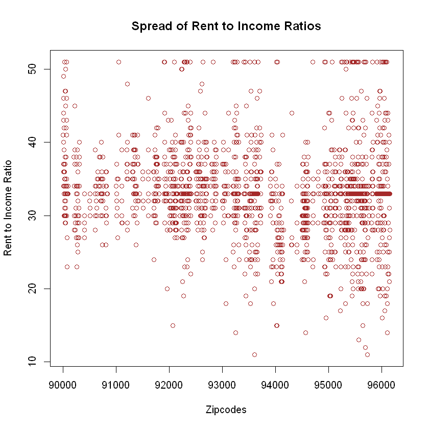

```r
# Using plot to identify and observe spread of rent to Income Ratios througout Stockton, naming and coloring for
# variable represented income and variable represented ratio
plot(data2$Zipcode,data2$Ratio, "p", ylab="Rent to Income Ratio", col = "brown" , xlab="Zipcodes", main="Spread of Rent to Income Ratios")
```

```r
library(ggplot2)
library(psych)
library(RColorBrewer)
library(corrplot)
library(MASS)
library("plot3D")
library(lattice)
library(reshape)
```

### 5.2 Descriptive Visualization using Piechart:

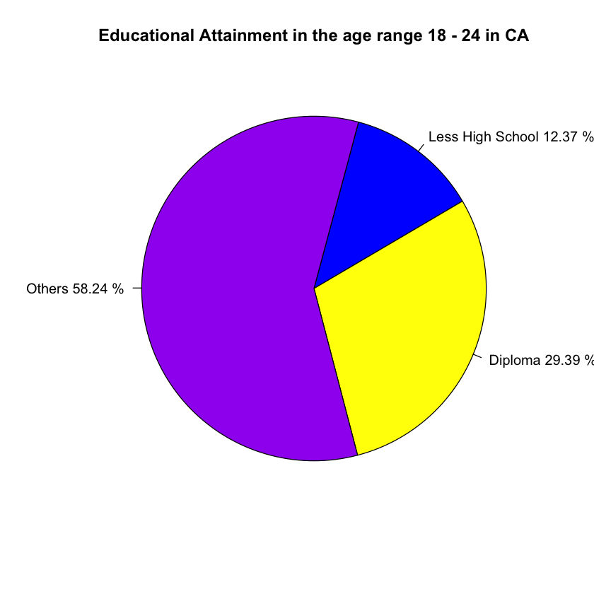

```r
#Summing the columns of interests using
#Less.than.hs.proportion
#diploma.Proportion
#bachelors.proportion
#Total.Pop.18.24
sumLHS <- sum(data2$less.than.hs.proportion, na.rm = TRUE)
sumNUM.LHS <- sum(data2$Total.Num.of.People.Less.Than.Highschool,na.rm = TRUE)
sum18.24 <- sum(data2$Total.Pop.18.24,na.rm = TRUE)
sumNUM.DIP <- sum(data2$Total.Num.Diploma.Received,na.rm = TRUE)

# Let's calculate the percentage of residents with education less than high school
# compared to ones with diploma in this age range.
pct=(sumNUM.LHS/sum18.24)*100
pct2=(sumNUM.DIP/sum18.24)*100
pct3 = 100 - pct - pct2

datapie <- c(round(pct,2),round(pct2,2),round(pct3,2))

# Let's create and design the pie chart from what we have.
labels=c("Less High School","Diploma","Others")
labels = paste(labels,datapie, "%")
col=c("blue","yellow","purple")
pie(datapie,col = col, radius=0.85,init.angle=75,clockwise=TRUE,
    labels=labels, main = "Educational Attainment in the age range 18 - 24 in CA")
```

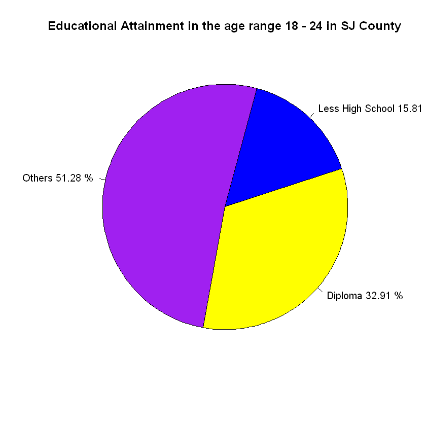

```r
#Summing the columns of interests using
#Less.than.hs.proportion
#diploma.Proportion
#bachelors.proportion
#Total.Pop.18.24
sumLHS <- sum(county.SJ$less.than.hs.proportion, na.rm = TRUE)
sumNUM.LHS <- sum(county.SJ$Total.Num.of.People.Less.Than.Highschool,na.rm = TRUE)
sum18.24 <- sum(county.SJ$Total.Pop.18.24,na.rm = TRUE)
sumNUM.DIP <- sum(county.SJ$Total.Num.Diploma.Received,na.rm = TRUE)

# Let's calculate the percentage of residents with education less than high school
# compared to ones with diploma in this age range.
pct=(sumNUM.LHS/sum18.24)*100
pct2=(sumNUM.DIP/sum18.24)*100
pct3 = 100 - pct - pct2

datapie <- c(round(pct,2),round(pct2,2),round(pct3,2))


# Let's create and design the pie chart from what we have.
labels=c("Less High School","Diploma","Others")
labels = paste(labels,datapie, "%")
col=c("blue","yellow","purple")
pie(datapie,col = col, radius=0.85,init.angle=75,clockwise=TRUE,
    labels=labels, main = "Educational Attainment in the age range 18 - 24 in SJ County")
```

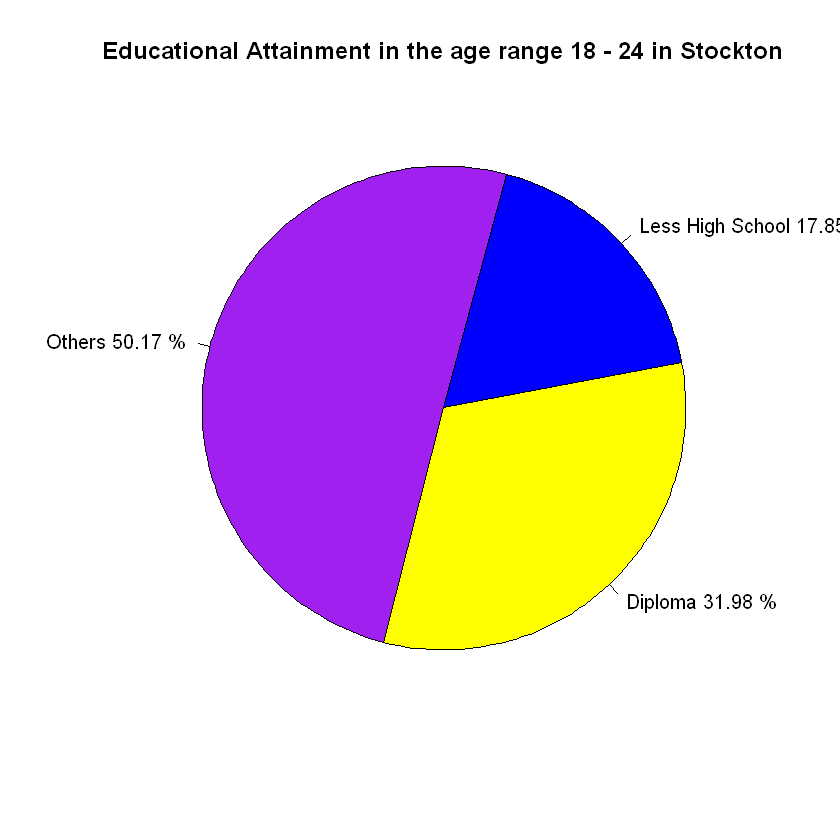

```r
#Summing the columns of interests using
#Less.than.hs.proportion
#diploma.Proportion
#bachelors.proportion
#Total.Pop.18.24
sumLHS <- sum(stkn$less.than.hs.proportion, na.rm = TRUE)
sumNUM.LHS <- sum(stkn$Total.Num.of.People.Less.Than.Highschool,na.rm = TRUE)
sum18.24 <- sum(stkn$Total.Pop.18.24,na.rm = TRUE)
sumNUM.DIP <- sum(stkn$Total.Num.Diploma.Received,na.rm = TRUE)

# Let's calculate the percentage of residents with education less than high school
# compared to ones with diploma in this age range.
pct=(sumNUM.LHS/sum18.24)*100
pct2=(sumNUM.DIP/sum18.24)*100
pct3 = 100 - pct - pct2

datapie <- c(round(pct,2),round(pct2,2),round(pct3,2))


# Let's create and design the pie chart from what we have.
labels=c("Less High School","Diploma","Others")
labels = paste(labels,datapie, "%")
col=c("blue","yellow","purple")
pie(datapie,col = col, radius=0.85,init.angle=75,clockwise=TRUE,
    labels=labels, main = "Educational Attainment in the age range 18 - 24 in Stockton")
```

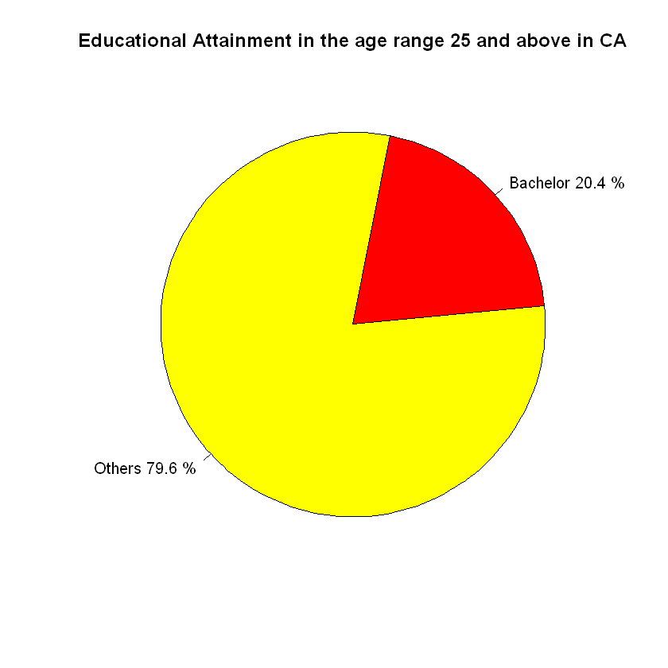

```r
# Creating separate pie chart for those who graduated with bachelor degree in the age range of
# 25 or above compared to the rest of that population in that age range.
# Total.Num.of.Bachelors.Degrees
# Total.Pop.25.and.over
sumNUM.BAC = sum(data2$Total.Num.of.Bachelors.Degrees,na.rm = TRUE)
sum25.above = sum(data2$Total.Pop.25.and.over,na.rm = TRUE)

# Let's calculate the percentage of residents with education achievement
# of bachelor degree compared to the whole popluate of 25 and above.
pct4=(sumNUM.BAC/sum25.above)*100
pct5 = 100 - pct4

datapie2 <- c(round(pct4,2),round(pct5,2))

# Let's create and design the pie chart from what we have.
labels1=c("Bachelor","Others")
labels1 = paste(labels1,datapie2, "%")
col=c("red","yellow")
pie(datapie2,col = col, radius=0.85,init.angle=79,clockwise=TRUE,
    labels=labels1, main = "Educational Attainment in the age range 25 and above in CA")
```

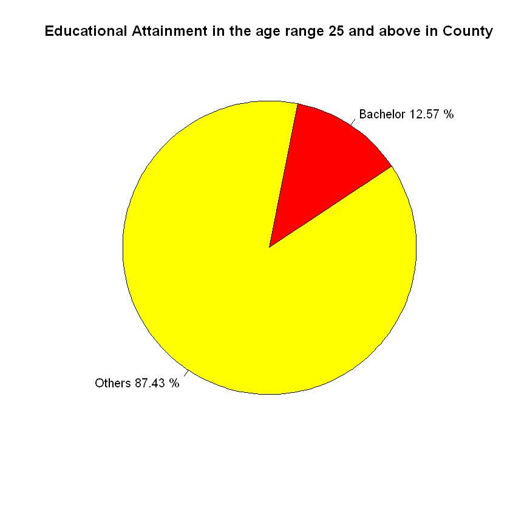

```r
# Creating separate pie chart for those who graduated with bachelor degree in the age range of
# 25 or above compared to the rest of that population in that age range.
# Total.Num.of.Bachelors.Degrees
# Total.Pop.25.and.over
sumNUM.BAC = sum(county.SJ$Total.Num.of.Bachelors.Degrees,na.rm = TRUE)
sum25.above = sum(county.SJ$Total.Pop.25.and.over,na.rm = TRUE)

# Let's calculate the percentage of residents with education achievement
# of bachelor degree compared to the whole popluate of 25 and above.
pct4=(sumNUM.BAC/sum25.above)*100
pct5 = 100 - pct4

datapie2 <- c(round(pct4,2),round(pct5,2))

# Let's create and design the pie chart from what we have.
labels1=c("Bachelor","Others")
labels1 = paste(labels1,datapie2, "%")
col=c("red","yellow")
pie(datapie2,col = col, radius=0.85,init.angle=79,clockwise=TRUE,
    labels=labels1, main = "Educational Attainment in the age range 25 and above in County")
```

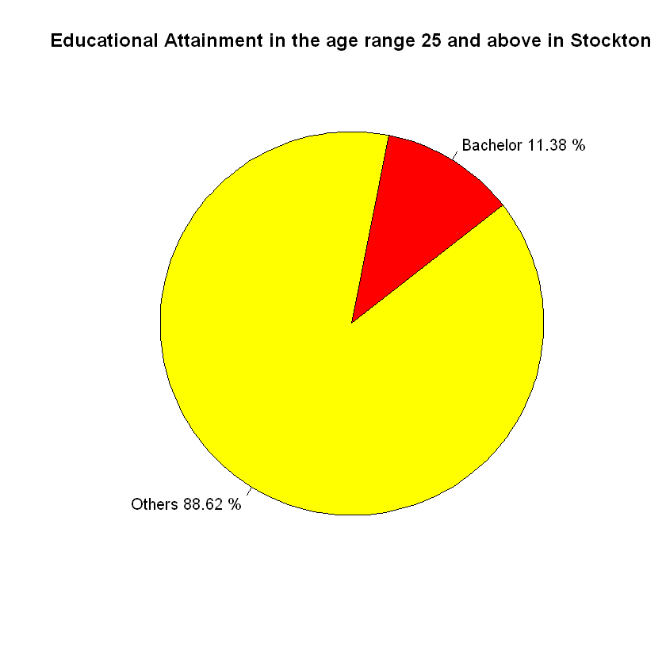

```r
# Creating separate pie chart for those who graduated with bachelor degree in the age range of
# 25 or above compared to the rest of that population in that age range.
# Total.Num.of.Bachelors.Degrees
# Total.Pop.25.and.over
sumNUM.BAC = sum(stkn$Total.Num.of.Bachelors.Degrees,na.rm = TRUE)
sum25.above = sum(stkn$Total.Pop.25.and.over,na.rm = TRUE)

# Let's calculate the percentage of residents with education achievement
# of bachelor degree compared to the whole popluate of 25 and above.
pct4=(sumNUM.BAC/sum25.above)*100
pct5 = 100 - pct4

datapie2 <- c(round(pct4,2),round(pct5,2))

# Let's create and design the pie chart from what we have.
labels1=c("Bachelor","Others")
labels1 = paste(labels1,datapie2, "%")
col=c("red","yellow")
pie(datapie2,col = col, radius=0.85,init.angle=79,clockwise=TRUE,
    labels=labels1, main = "Educational Attainment in the age range 25 and above in Stockton")
```

Base on these pie charts above, it is significant to realize that Stockton has the most signicant amount of highschool drop out (17.85%) in compare to ones of San Jaquin County and Claifornia. Meanwhile, the amount of residents attain bachelor in Stockton is the least in comparision to San Jaquin County and Claifornia. Education could really affect the job and living standard of people and let's dig deep in to these areas in later chapter of this notebook to find out the relations.

### 5.3 Descriptive Visualization using Box Plots

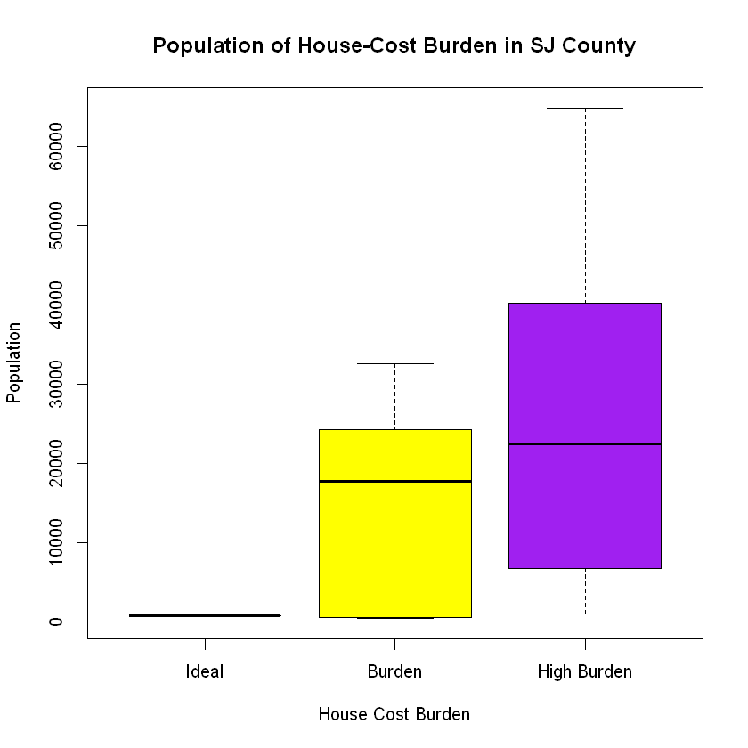

```r
county.SJ$Ratiorate <- 0

# Using the definitions of Housng-Cost Burden from the U.S. Bureau
county.SJ$Ratiorate[county.SJ$Ratio <=20 & county.SJ$Ratio==0] <- "ideal"
county.SJ$Ratiorate[county.SJ$Ratio <30 & county.SJ$Ratio >= 20 ] <- "burden"
county.SJ$Ratiorate[county.SJ$Ratio >= 30 & county.SJ$Ratio < 50  ] <- "high burden"
county.SJ$Ratiorate[county.SJ$Ratio >= 50 ] <- "extreme burden"

county.SJ$Ratiorate <- as.factor(county.SJ$Ratiorate)

boxplot( county.SJ$Population~ county.SJ$Ratiorate, data=county.SJ,xlab="House Cost Burden",
        ylab="Population",main="Population of House-Cost Burden in SJ County",
        col=c("green", "yellow","purple"),
        names=c("Ideal","Burden","High Burden"))
```

[figure not shown]

```r
## NOT SURE WE NEED THE ONE BELOW ITS FOR US

data2$Ratiorate <- 0

# Using the definitions of Housng-Cost Burden from the U.S. Bureau

data2$Ratiorate[data2$Ratio <=20 & data2$Ratio==0] <- "ideal"
data2$Ratiorate[data2$Ratio <30 & data2$Ratio >= 20 ] <- "burden"
data2$Ratiorate[data2$Ratio >= 30 & data2$Ratio < 50  ] <- "high burden"
data2$Ratiorate[data2$Ratio >= 50 ] <- "extreme burden"

data2$Ratiorate <- as.factor(data2$Ratiorate)

boxplot( data2$Population~ data2$Ratiorate, data=data2,xlab="House Cost Burden",ylab="Population",main="Population of House-Cost Burden in CA",col=c("green", "yellow","purple", "blue"), names=c("Ideal","Burden","High Burden", "Extreme Burden"))
```

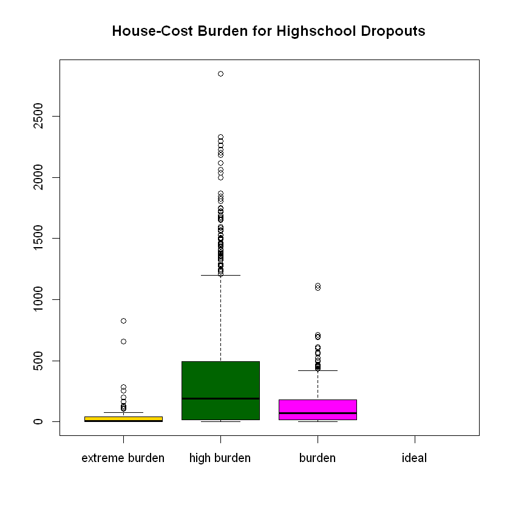

```r
# Let's compare it to the median of those has less than highschool education.
#Total.Num.of.People.Less.Than.Highschool
boxplot(data2[data2$Ratiorate=="extreme burden",]$Total.Num.of.People.Less.Than.Highschool,
        data2[data2$Ratiorate=="high burden",]$Total.Num.of.People.Less.Than.Highschool,
        data2[data2$Ratiorate=="burden",]$Total.Num.of.People.Less.Than.Highschool,
        data2[data2$Ratiorate=="ideal",]$Total.Num.of.People.Less.Than.Highschool,main = "House-Cost Burden for Highschool Dropouts",
        names=c("extreme burden","high burden","burden","ideal"),
        col=(c("gold","darkgreen","magenta","maroon")))
```

### 5.4 Descriptive Visualization Using Bar Graphs

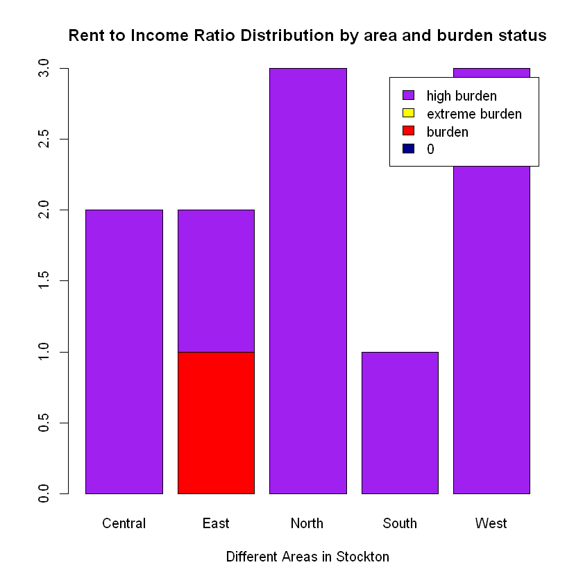

```r
# Let's see how the rent to income ration spread out over the whole population.
#Population

data2$ZipArea[data2$Zipcode == 95211 | data2$Zipcode == 95202 ] <- "Central"
data2$ZipArea[data2$Zipcode == 95209 | data2$Zipcode == 95207 | data2$Zipcode == 95212 ] <- "North"
data2$ZipArea[data2$Zipcode == 95206 ] <- "South"
data2$ZipArea[data2$Zipcode == 95205 |data2$Zipcode == 95215 ] <- "East"
data2$ZipArea[data2$Zipcode == 95219 |data2$Zipcode == 95204 | data2$Zipcode == 95203 ] <- "West"

counts <- table(data2$Ratiorate, data2$ZipArea)
barplot(counts, main="Rent to Income Ratio Distribution by area and burden status",
  xlab="Different Areas in Stockton", col=c("darkblue","red","yellow","purple","white"),
  legend = rownames(counts))
```

It is supprising sad that base on this visualization, we could notice that high burden spread significantly into different areas of stockton where East has a better living standard but still exist equal amount of those burden compared to those less burden. The rest are almost equal. Supprisingly, South Stockton are targeted by San Jaquen county for the rural and low living standard but this chart only show less signicant amount of burden status compare to other areas. However, we could realize that not enough sufficiant data could cause us to not have the comprehensive picture of the areas we targeted on.

## Linear Regression:

### 7. Explore Correlations:

#### Pairwise

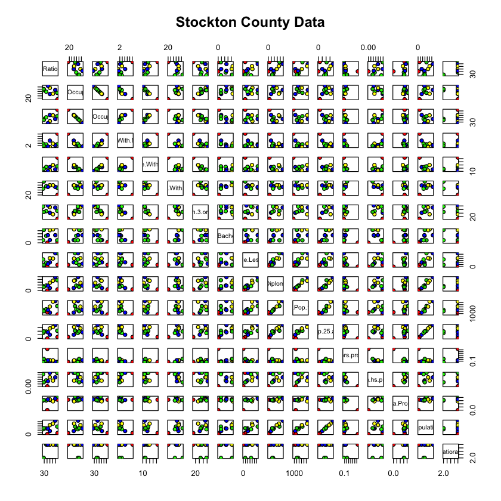

```r
# Utilizing Pairwise function to explore the correlations of stockton data
# to define any potential relationship
# and to dig deep into define the relationship and correlations among variables.
pairs(stkn[3:19], main="Stockton County Data", pch=21,
     bg=c("red","blue","green","green3","blue2","yellow","yellow2"))
```

Looking at this pairwise, it is significant to define that there are somehow realtionship between income to rent ratio in the relation with population, out of highschool population, renter occupied, 18-24 population and 25 and above population. These pair indicatings the same direction of the dots representing variances and provide comprehensie overview of which aspects we should dig deep in to discovery through simple linear regression and multiple linear regression.In the next section, we will dig deep into these direction to predict the potential direction of these relationships.There are insignificant correlation among other realtionship indicating through pairwise.